# Risk Factor Analysis

## Outcome Variable

**Outcome Variable:** ever_wasted

## Predictor Variables

**Intervention Variable:** parity

**Adjustment Set:**

- arm
- W_mage
- meducyrs
- feducyrs
- hhwealth_quart
- W_mhtcm
- vagbrth
- W_nrooms
- impsan
- delta_W_mage
- delta_meducyrs
- delta_feducyrs
- delta_hhwealth_quart
- delta_W_mhtcm
- delta_vagbrth
- delta_W_nrooms
- delta_impsan

## Stratifying Variables

The analysis was stratified on these variable(s):

- agecat
- studyid
- country

## Data Summary

| agecat | studyid | country | parity | ever_wasted | n_cell | n |
| --- | --- | --- | --- | --- | --- | --- |
| 0-24 months | ki1000304b-SAS-CompFeed | INDIA | 1 | 0 | 273 | 1513 |
| 0-24 months | ki1000304b-SAS-CompFeed | INDIA | 1 | 1 | 175 | 1513 |
| 0-24 months | ki1000304b-SAS-CompFeed | INDIA | 2 | 0 | 219 | 1513 |
| 0-24 months | ki1000304b-SAS-CompFeed | INDIA | 2 | 1 | 135 | 1513 |
| 0-24 months | ki1000304b-SAS-CompFeed | INDIA | 3+ | 0 | 393 | 1513 |
| 0-24 months | ki1000304b-SAS-CompFeed | INDIA | 3+ | 1 | 318 | 1513 |
| 0-24 months | ki1000304b-SAS-FoodSuppl | INDIA | 1 | 0 | 51 | 397 |
| 0-24 months | ki1000304b-SAS-FoodSuppl | INDIA | 1 | 1 | 26 | 397 |
| 0-24 months | ki1000304b-SAS-FoodSuppl | INDIA | 2 | 0 | 46 | 397 |
| 0-24 months | ki1000304b-SAS-FoodSuppl | INDIA | 2 | 1 | 46 | 397 |
| 0-24 months | ki1000304b-SAS-FoodSuppl | INDIA | 3+ | 0 | 112 | 397 |
| 0-24 months | ki1000304b-SAS-FoodSuppl | INDIA | 3+ | 1 | 116 | 397 |
| 0-24 months | ki1017093b-PROVIDE | BANGLADESH | 1 | 0 | 163 | 700 |
| 0-24 months | ki1017093b-PROVIDE | BANGLADESH | 1 | 1 | 108 | 700 |
| 0-24 months | ki1017093b-PROVIDE | BANGLADESH | 2 | 0 | 170 | 700 |
| 0-24 months | ki1017093b-PROVIDE | BANGLADESH | 2 | 1 | 74 | 700 |
| 0-24 months | ki1017093b-PROVIDE | BANGLADESH | 3+ | 0 | 121 | 700 |
| 0-24 months | ki1017093b-PROVIDE | BANGLADESH | 3+ | 1 | 64 | 700 |
| 0-24 months | ki1066203-TanzaniaChild2 | TANZANIA, UNITED REPUBLIC OF | 1 | 0 | 624 | 2357 |
| 0-24 months | ki1066203-TanzaniaChild2 | TANZANIA, UNITED REPUBLIC OF | 1 | 1 | 197 | 2357 |
| 0-24 months | ki1066203-TanzaniaChild2 | TANZANIA, UNITED REPUBLIC OF | 2 | 0 | 583 | 2357 |
| 0-24 months | ki1066203-TanzaniaChild2 | TANZANIA, UNITED REPUBLIC OF | 2 | 1 | 188 | 2357 |
| 0-24 months | ki1066203-TanzaniaChild2 | TANZANIA, UNITED REPUBLIC OF | 3+ | 0 | 592 | 2357 |
| 0-24 months | ki1066203-TanzaniaChild2 | TANZANIA, UNITED REPUBLIC OF | 3+ | 1 | 173 | 2357 |
| 0-24 months | ki1101329-Keneba | GAMBIA | 1 | 0 | 160 | 1989 |
| 0-24 months | ki1101329-Keneba | GAMBIA | 1 | 1 | 80 | 1989 |
| 0-24 months | ki1101329-Keneba | GAMBIA | 2 | 0 | 138 | 1989 |
| 0-24 months | ki1101329-Keneba | GAMBIA | 2 | 1 | 76 | 1989 |
| 0-24 months | ki1101329-Keneba | GAMBIA | 3+ | 0 | 887 | 1989 |
| 0-24 months | ki1101329-Keneba | GAMBIA | 3+ | 1 | 648 | 1989 |

[output cut: 168 more lines]

The following strata were considered:

- agecat: 0-24 months, studyid: ki1000304b-SAS-CompFeed, country: INDIA
- agecat: 0-24 months, studyid: ki1000304b-SAS-FoodSuppl, country: INDIA
- agecat: 0-24 months, studyid: ki1017093b-PROVIDE, country: BANGLADESH
- agecat: 0-24 months, studyid: ki1066203-TanzaniaChild2, country: TANZANIA, UNITED REPUBLIC OF
- agecat: 0-24 months, studyid: ki1101329-Keneba, country: GAMBIA
- agecat: 0-24 months, studyid: ki1113344-GMS-Nepal, country: NEPAL
- agecat: 0-24 months, studyid: ki1126311-ZVITAMBO, country: ZIMBABWE
- agecat: 0-24 months, studyid: ki1135781-COHORTS, country: GUATEMALA
- agecat: 0-24 months, studyid: ki1135781-COHORTS, country: INDIA
- agecat: 0-24 months, studyid: ki1135781-COHORTS, country: PHILIPPINES
- agecat: 0-24 months, studyid: kiGH5241-JiVitA-3, country: BANGLADESH
- agecat: 0-6 months, studyid: ki1000304b-SAS-CompFeed, country: INDIA
- agecat: 0-6 months, studyid: ki1000304b-SAS-FoodSuppl, country: INDIA
- agecat: 0-6 months, studyid: ki1017093b-PROVIDE, country: BANGLADESH
- agecat: 0-6 months, studyid: ki1066203-TanzaniaChild2, country: TANZANIA, UNITED REPUBLIC OF
- agecat: 0-6 months, studyid: ki1101329-Keneba, country: GAMBIA
- agecat: 0-6 months, studyid: ki1113344-GMS-Nepal, country: NEPAL
- agecat: 0-6 months, studyid: ki1126311-ZVITAMBO, country: ZIMBABWE
- agecat: 0-6 months, studyid: ki1135781-COHORTS, country: GUATEMALA
- agecat: 0-6 months, studyid: ki1135781-COHORTS, country: INDIA
- agecat: 0-6 months, studyid: ki1135781-COHORTS, country: PHILIPPINES
- agecat: 0-6 months, studyid: kiGH5241-JiVitA-3, country: BANGLADESH
- agecat: 6-24 months, studyid: ki1000304b-SAS-CompFeed, country: INDIA
- agecat: 6-24 months, studyid: ki1000304b-SAS-FoodSuppl, country: INDIA
- agecat: 6-24 months, studyid: ki1017093b-PROVIDE, country: BANGLADESH
- agecat: 6-24 months, studyid: ki1066203-TanzaniaChild2, country: TANZANIA, UNITED REPUBLIC OF
- agecat: 6-24 months, studyid: ki1101329-Keneba, country: GAMBIA
- agecat: 6-24 months, studyid: ki1113344-GMS-Nepal, country: NEPAL
- agecat: 6-24 months, studyid: ki1126311-ZVITAMBO, country: ZIMBABWE
- agecat: 6-24 months, studyid: ki1135781-COHORTS, country: GUATEMALA
- agecat: 6-24 months, studyid: ki1135781-COHORTS, country: INDIA
- agecat: 6-24 months, studyid: ki1135781-COHORTS, country: PHILIPPINES
- agecat: 6-24 months, studyid: kiGH5241-JiVitA-3, country: BANGLADESH

## Methods Detail

We’re interested in the causal parameters $E[Y_a]$ for all values of $a \in \mathcal{A}$. These parameters represent the mean outcome if, possibly contrary to fact, we intervened to set all units to have $A=a$. Under the randomization and positivity assumptions, these are identified by the statistical parameters $\psi_a=E_W[E_{Y|A,W}(Y|A=a,W)]$. In addition, we’re interested in the mean of $Y$, $E[Y]$ under no intervention (the observed mean). We will estimate these parameters by using SuperLearner to fit the relevant likelihood factors – $E_{Y|A,W}(Y|A=a,W)$ and $p(A=a|W)$, and then updating our likelihood fit using a joint TMLE.

For unadjusted analyses ($W=\{\}$), initial likelihoods were estimated using Lrnr_glm to estimate the simple $E(Y|A)$ and Lrnr_mean to estimate $p(A)$. For adjusted analyses, a small library containing Lrnr_glmnet, Lrnr_xgboost, and Lrnr_mean was used.

Having estimated these parameters, we will then use the delta method to estimate relative risks and attributable risks relative to a prespecified baseline level of $A$.

# Results Detail

## Results Plots

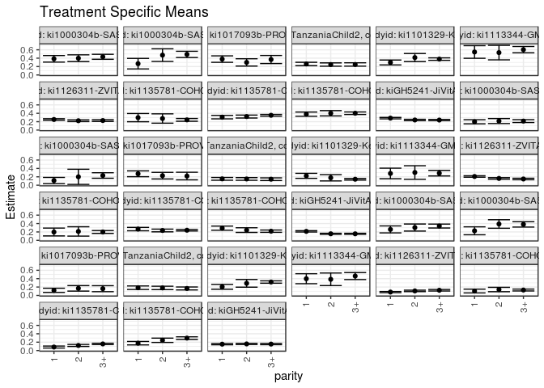

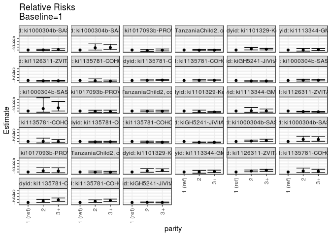

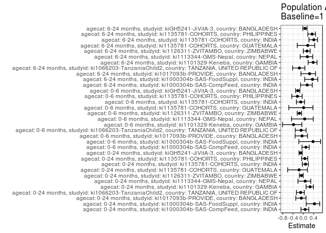

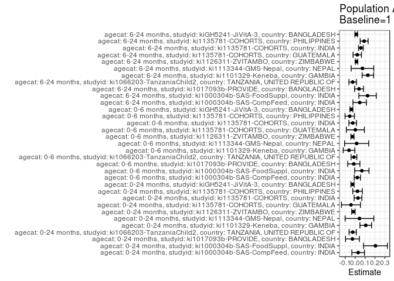

## Results Table

### Parameter: TSM

| agecat | studyid | country | intervention_level | baseline_level | estimate | ci_lower | ci_upper |
| --- | --- | --- | --- | --- | --- | --- | --- |
| 0-24 months | ki1000304b-SAS-CompFeed | INDIA | 1 | NA | 0.3845938 | 0.3058615 | 0.4633260 |
| 0-24 months | ki1000304b-SAS-CompFeed | INDIA | 2 | NA | 0.3989501 | 0.3185559 | 0.4793443 |
| 0-24 months | ki1000304b-SAS-CompFeed | INDIA | 3+ | NA | 0.4330229 | 0.3735035 | 0.4925422 |
| 0-24 months | ki1000304b-SAS-FoodSuppl | INDIA | 1 | NA | 0.2688421 | 0.1430305 | 0.3946537 |
| 0-24 months | ki1000304b-SAS-FoodSuppl | INDIA | 2 | NA | 0.4726110 | 0.3218607 | 0.6233612 |
| 0-24 months | ki1000304b-SAS-FoodSuppl | INDIA | 3+ | NA | 0.4903278 | 0.4158125 | 0.5648431 |
| 0-24 months | ki1017093b-PROVIDE | BANGLADESH | 1 | NA | 0.3783520 | 0.3010599 | 0.4556441 |
| 0-24 months | ki1017093b-PROVIDE | BANGLADESH | 2 | NA | 0.2990123 | 0.2118408 | 0.3861837 |
| 0-24 months | ki1017093b-PROVIDE | BANGLADESH | 3+ | NA | 0.3681603 | 0.2720578 | 0.4642628 |
| 0-24 months | ki1066203-TanzaniaChild2 | TANZANIA, UNITED REPUBLIC OF | 1 | NA | 0.2612310 | 0.2207827 | 0.3016793 |
| 0-24 months | ki1066203-TanzaniaChild2 | TANZANIA, UNITED REPUBLIC OF | 2 | NA | 0.2484054 | 0.2090134 | 0.2877974 |
| 0-24 months | ki1066203-TanzaniaChild2 | TANZANIA, UNITED REPUBLIC OF | 3+ | NA | 0.2496782 | 0.2098243 | 0.2895321 |
| 0-24 months | ki1101329-Keneba | GAMBIA | 1 | NA | 0.2972730 | 0.2387008 | 0.3558453 |
| 0-24 months | ki1101329-Keneba | GAMBIA | 2 | NA | 0.4147223 | 0.3182977 | 0.5111470 |
| 0-24 months | ki1101329-Keneba | GAMBIA | 3+ | NA | 0.3781925 | 0.3482338 | 0.4081513 |
| 0-24 months | ki1113344-GMS-Nepal | NEPAL | 1 | NA | 0.5476550 | 0.3972490 | 0.6980611 |
| 0-24 months | ki1113344-GMS-Nepal | NEPAL | 2 | NA | 0.5329953 | 0.3598526 | 0.7061379 |
| 0-24 months | ki1113344-GMS-Nepal | NEPAL | 3+ | NA | 0.6031559 | 0.5277286 | 0.6785832 |
| 0-24 months | ki1126311-ZVITAMBO | ZIMBABWE | 1 | NA | 0.2522377 | 0.2337793 | 0.2706960 |
| 0-24 months | ki1126311-ZVITAMBO | ZIMBABWE | 2 | NA | 0.2229914 | 0.2027962 | 0.2431867 |
| 0-24 months | ki1126311-ZVITAMBO | ZIMBABWE | 3+ | NA | 0.2274755 | 0.2064096 | 0.2485414 |
| 0-24 months | ki1135781-COHORTS | GUATEMALA | 1 | NA | 0.2966391 | 0.1986771 | 0.3946011 |
| 0-24 months | ki1135781-COHORTS | GUATEMALA | 2 | NA | 0.2755822 | 0.1644159 | 0.3867486 |
| 0-24 months | ki1135781-COHORTS | GUATEMALA | 3+ | NA | 0.2432002 | 0.2105525 | 0.2758479 |
| 0-24 months | ki1135781-COHORTS | INDIA | 1 | NA | 0.3087790 | 0.2676059 | 0.3499520 |
| 0-24 months | ki1135781-COHORTS | INDIA | 2 | NA | 0.3224005 | 0.2873244 | 0.3574766 |
| 0-24 months | ki1135781-COHORTS | INDIA | 3+ | NA | 0.3523010 | 0.3316077 | 0.3729943 |
| 0-24 months | ki1135781-COHORTS | PHILIPPINES | 1 | NA | 0.3795301 | 0.3290091 | 0.4300512 |
| 0-24 months | ki1135781-COHORTS | PHILIPPINES | 2 | NA | 0.4005532 | 0.3375144 | 0.4635920 |
| 0-24 months | ki1135781-COHORTS | PHILIPPINES | 3+ | NA | 0.4020100 | 0.3715999 | 0.4324201 |

[output cut: 69 more lines]

### Parameter: E(Y)

| agecat | studyid | country | intervention_level | baseline_level | estimate | ci_lower | ci_upper |
| --- | --- | --- | --- | --- | --- | --- | --- |
| 0-24 months | ki1000304b-SAS-CompFeed | INDIA | NA | NA | 0.4150694 | 0.3581204 | 0.4720184 |
| 0-24 months | ki1000304b-SAS-FoodSuppl | INDIA | NA | NA | 0.4735516 | 0.4243746 | 0.5227286 |
| 0-24 months | ki1017093b-PROVIDE | BANGLADESH | NA | NA | 0.3514286 | 0.3160364 | 0.3868207 |
| 0-24 months | ki1066203-TanzaniaChild2 | TANZANIA, UNITED REPUBLIC OF | NA | NA | 0.2367416 | 0.2195770 | 0.2539062 |
| 0-24 months | ki1101329-Keneba | GAMBIA | NA | NA | 0.4042232 | 0.3826511 | 0.4257953 |
| 0-24 months | ki1113344-GMS-Nepal | NEPAL | NA | NA | 0.5913621 | 0.5520608 | 0.6306634 |
| 0-24 months | ki1126311-ZVITAMBO | ZIMBABWE | NA | NA | 0.2347539 | 0.2277172 | 0.2417906 |
| 0-24 months | ki1135781-COHORTS | GUATEMALA | NA | NA | 0.2550336 | 0.2316956 | 0.2783715 |
| 0-24 months | ki1135781-COHORTS | INDIA | NA | NA | 0.3378028 | 0.3241691 | 0.3514364 |
| 0-24 months | ki1135781-COHORTS | PHILIPPINES | NA | NA | 0.4036125 | 0.3861835 | 0.4210415 |
| 0-24 months | kiGH5241-JiVitA-3 | BANGLADESH | NA | NA | 0.2580286 | 0.2515670 | 0.2644901 |
| 0-6 months | ki1000304b-SAS-CompFeed | INDIA | NA | NA | 0.2199336 | 0.1753445 | 0.2645227 |
| 0-6 months | ki1000304b-SAS-FoodSuppl | INDIA | NA | NA | 0.1788413 | 0.1410973 | 0.2165853 |
| 0-6 months | ki1017093b-PROVIDE | BANGLADESH | NA | NA | 0.2585714 | 0.2261125 | 0.2910304 |
| 0-6 months | ki1066203-TanzaniaChild2 | TANZANIA, UNITED REPUBLIC OF | NA | NA | 0.1395842 | 0.1255905 | 0.1535779 |
| 0-6 months | ki1101329-Keneba | GAMBIA | NA | NA | 0.1613611 | 0.1444653 | 0.1782570 |
| 0-6 months | ki1113344-GMS-Nepal | NEPAL | NA | NA | 0.2956811 | 0.2591967 | 0.3321655 |
| 0-6 months | ki1126311-ZVITAMBO | ZIMBABWE | NA | NA | 0.1810631 | 0.1746489 | 0.1874773 |
| 0-6 months | ki1135781-COHORTS | GUATEMALA | NA | NA | 0.2003763 | 0.1763021 | 0.2244505 |
| 0-6 months | ki1135781-COHORTS | INDIA | NA | NA | 0.2434743 | 0.2308547 | 0.2560940 |
| 0-6 months | ki1135781-COHORTS | PHILIPPINES | NA | NA | 0.2355453 | 0.2204685 | 0.2506222 |
| 0-6 months | kiGH5241-JiVitA-3 | BANGLADESH | NA | NA | 0.1762799 | 0.1706566 | 0.1819032 |
| 6-24 months | ki1000304b-SAS-CompFeed | INDIA | NA | NA | 0.3059755 | 0.2638053 | 0.3481458 |
| 6-24 months | ki1000304b-SAS-FoodSuppl | INDIA | NA | NA | 0.3518987 | 0.3047435 | 0.3990540 |
| 6-24 months | ki1017093b-PROVIDE | BANGLADESH | NA | NA | 0.1609756 | 0.1319065 | 0.1900447 |
| 6-24 months | ki1066203-TanzaniaChild2 | TANZANIA, UNITED REPUBLIC OF | NA | NA | 0.1600403 | 0.1439152 | 0.1761654 |
| 6-24 months | ki1101329-Keneba | GAMBIA | NA | NA | 0.3341996 | 0.3131165 | 0.3552826 |
| 6-24 months | ki1113344-GMS-Nepal | NEPAL | NA | NA | 0.4728814 | 0.4325613 | 0.5132014 |
| 6-24 months | ki1126311-ZVITAMBO | ZIMBABWE | NA | NA | 0.0939867 | 0.0884555 | 0.0995179 |
| 6-24 months | ki1135781-COHORTS | GUATEMALA | NA | NA | 0.1269580 | 0.1082147 | 0.1457012 |
| 6-24 months | ki1135781-COHORTS | INDIA | NA | NA | 0.1419682 | 0.1315821 | 0.1523542 |
| 6-24 months | ki1135781-COHORTS | PHILIPPINES | NA | NA | 0.2666429 | 0.2502871 | 0.2829988 |
| 6-24 months | kiGH5241-JiVitA-3 | BANGLADESH | NA | NA | 0.1638036 | 0.1576801 | 0.1699271 |

### Parameter: RR

| agecat | studyid | country | intervention_level | baseline_level | estimate | ci_lower | ci_upper |
| --- | --- | --- | --- | --- | --- | --- | --- |
| 0-24 months | ki1000304b-SAS-CompFeed | INDIA | 1 | 1 | 1.0000000 | 1.0000000 | 1.0000000 |
| 0-24 months | ki1000304b-SAS-CompFeed | INDIA | 2 | 1 | 1.0373286 | 0.8555510 | 1.2577282 |
| 0-24 months | ki1000304b-SAS-CompFeed | INDIA | 3+ | 1 | 1.1259228 | 0.9029538 | 1.4039500 |
| 0-24 months | ki1000304b-SAS-FoodSuppl | INDIA | 1 | 1 | 1.0000000 | 1.0000000 | 1.0000000 |
| 0-24 months | ki1000304b-SAS-FoodSuppl | INDIA | 2 | 1 | 1.7579500 | 0.9993341 | 3.0924476 |
| 0-24 months | ki1000304b-SAS-FoodSuppl | INDIA | 3+ | 1 | 1.8238506 | 1.1148467 | 2.9837563 |
| 0-24 months | ki1017093b-PROVIDE | BANGLADESH | 1 | 1 | 1.0000000 | 1.0000000 | 1.0000000 |
| 0-24 months | ki1017093b-PROVIDE | BANGLADESH | 2 | 1 | 0.7903018 | 0.5536304 | 1.1281480 |
| 0-24 months | ki1017093b-PROVIDE | BANGLADESH | 3+ | 1 | 0.9730629 | 0.6985783 | 1.3553977 |
| 0-24 months | ki1066203-TanzaniaChild2 | TANZANIA, UNITED REPUBLIC OF | 1 | 1 | 1.0000000 | 1.0000000 | 1.0000000 |
| 0-24 months | ki1066203-TanzaniaChild2 | TANZANIA, UNITED REPUBLIC OF | 2 | 1 | 0.9509033 | 0.7620721 | 1.1865245 |
| 0-24 months | ki1066203-TanzaniaChild2 | TANZANIA, UNITED REPUBLIC OF | 3+ | 1 | 0.9557755 | 0.7650734 | 1.1940120 |
| 0-24 months | ki1101329-Keneba | GAMBIA | 1 | 1 | 1.0000000 | 1.0000000 | 1.0000000 |
| 0-24 months | ki1101329-Keneba | GAMBIA | 2 | 1 | 1.3950891 | 1.0285843 | 1.8921866 |
| 0-24 months | ki1101329-Keneba | GAMBIA | 3+ | 1 | 1.2722061 | 1.0287108 | 1.5733366 |
| 0-24 months | ki1113344-GMS-Nepal | NEPAL | 1 | 1 | 1.0000000 | 1.0000000 | 1.0000000 |
| 0-24 months | ki1113344-GMS-Nepal | NEPAL | 2 | 1 | 0.9732317 | 0.6360160 | 1.4892394 |
| 0-24 months | ki1113344-GMS-Nepal | NEPAL | 3+ | 1 | 1.1013428 | 0.8143024 | 1.4895643 |
| 0-24 months | ki1126311-ZVITAMBO | ZIMBABWE | 1 | 1 | 1.0000000 | 1.0000000 | 1.0000000 |
| 0-24 months | ki1126311-ZVITAMBO | ZIMBABWE | 2 | 1 | 0.8840529 | 0.7868899 | 0.9932133 |
| 0-24 months | ki1126311-ZVITAMBO | ZIMBABWE | 3+ | 1 | 0.9018300 | 0.8014350 | 1.0148014 |
| 0-24 months | ki1135781-COHORTS | GUATEMALA | 1 | 1 | 1.0000000 | 1.0000000 | 1.0000000 |
| 0-24 months | ki1135781-COHORTS | GUATEMALA | 2 | 1 | 0.9290153 | 0.5514075 | 1.5652115 |
| 0-24 months | ki1135781-COHORTS | GUATEMALA | 3+ | 1 | 0.8198521 | 0.5738865 | 1.1712378 |
| 0-24 months | ki1135781-COHORTS | INDIA | 1 | 1 | 1.0000000 | 1.0000000 | 1.0000000 |
| 0-24 months | ki1135781-COHORTS | INDIA | 2 | 1 | 1.0441144 | 0.8790535 | 1.2401689 |
| 0-24 months | ki1135781-COHORTS | INDIA | 3+ | 1 | 1.1409489 | 0.9862640 | 1.3198944 |
| 0-24 months | ki1135781-COHORTS | PHILIPPINES | 1 | 1 | 1.0000000 | 1.0000000 | 1.0000000 |
| 0-24 months | ki1135781-COHORTS | PHILIPPINES | 2 | 1 | 1.0553923 | 0.8588119 | 1.2969695 |
| 0-24 months | ki1135781-COHORTS | PHILIPPINES | 3+ | 1 | 1.0592307 | 0.9088746 | 1.2344604 |

[output cut: 69 more lines]

### Parameter: PAR

| agecat | studyid | country | intervention_level | baseline_level | estimate | ci_lower | ci_upper |
| --- | --- | --- | --- | --- | --- | --- | --- |
| 0-24 months | ki1000304b-SAS-CompFeed | INDIA | 1 | NA | 0.0304756 | -0.0329441 | 0.0938954 |
| 0-24 months | ki1000304b-SAS-FoodSuppl | INDIA | 1 | NA | 0.2047095 | 0.0841381 | 0.3252810 |
| 0-24 months | ki1017093b-PROVIDE | BANGLADESH | 1 | NA | -0.0269234 | -0.0961970 | 0.0423502 |
| 0-24 months | ki1066203-TanzaniaChild2 | TANZANIA, UNITED REPUBLIC OF | 1 | NA | -0.0244894 | -0.0606664 | 0.0116877 |
| 0-24 months | ki1101329-Keneba | GAMBIA | 1 | NA | 0.1069502 | 0.0484901 | 0.1654103 |
| 0-24 months | ki1113344-GMS-Nepal | NEPAL | 1 | NA | 0.0437071 | -0.1009590 | 0.1883732 |
| 0-24 months | ki1126311-ZVITAMBO | ZIMBABWE | 1 | NA | -0.0174837 | -0.0344637 | -0.0005038 |
| 0-24 months | ki1135781-COHORTS | GUATEMALA | 1 | NA | -0.0416055 | -0.1372528 | 0.0540418 |
| 0-24 months | ki1135781-COHORTS | INDIA | 1 | NA | 0.0290238 | -0.0102259 | 0.0682735 |
| 0-24 months | ki1135781-COHORTS | PHILIPPINES | 1 | NA | 0.0240823 | -0.0239828 | 0.0721474 |
| 0-24 months | kiGH5241-JiVitA-3 | BANGLADESH | 1 | NA | -0.0264802 | -0.0423922 | -0.0105683 |
| 0-6 months | ki1000304b-SAS-CompFeed | INDIA | 1 | NA | 0.0218951 | -0.0095744 | 0.0533647 |
| 0-6 months | ki1000304b-SAS-FoodSuppl | INDIA | 1 | NA | 0.0675233 | -0.0046018 | 0.1396483 |
| 0-6 months | ki1017093b-PROVIDE | BANGLADESH | 1 | NA | -0.0133182 | -0.0747422 | 0.0481059 |
| 0-6 months | ki1066203-TanzaniaChild2 | TANZANIA, UNITED REPUBLIC OF | 1 | NA | -0.0117011 | -0.0408293 | 0.0174270 |
| 0-6 months | ki1101329-Keneba | GAMBIA | 1 | NA | -0.0614952 | -0.1204083 | -0.0025820 |
| 0-6 months | ki1113344-GMS-Nepal | NEPAL | 1 | NA | 0.0155646 | -0.1060319 | 0.1371611 |
| 0-6 months | ki1126311-ZVITAMBO | ZIMBABWE | 1 | NA | -0.0270371 | -0.0425012 | -0.0115731 |
| 0-6 months | ki1135781-COHORTS | GUATEMALA | 1 | NA | 0.0023162 | -0.0884667 | 0.0930990 |
| 0-6 months | ki1135781-COHORTS | INDIA | 1 | NA | -0.0241152 | -0.0624499 | 0.0142195 |
| 0-6 months | ki1135781-COHORTS | PHILIPPINES | 1 | NA | -0.0543335 | -0.1014210 | -0.0072460 |
| 0-6 months | kiGH5241-JiVitA-3 | BANGLADESH | 1 | NA | -0.0373919 | -0.0520352 | -0.0227486 |
| 6-24 months | ki1000304b-SAS-CompFeed | INDIA | 1 | NA | 0.0460037 | -0.0219526 | 0.1139600 |
| 6-24 months | ki1000304b-SAS-FoodSuppl | INDIA | 1 | NA | 0.1253301 | 0.0376434 | 0.2130168 |
| 6-24 months | ki1017093b-PROVIDE | BANGLADESH | 1 | NA | 0.0392029 | -0.0058183 | 0.0842242 |
| 6-24 months | ki1066203-TanzaniaChild2 | TANZANIA, UNITED REPUBLIC OF | 1 | NA | -0.0243907 | -0.0622175 | 0.0134361 |
| 6-24 months | ki1101329-Keneba | GAMBIA | 1 | NA | 0.1284590 | 0.0705225 | 0.1863955 |
| 6-24 months | ki1113344-GMS-Nepal | NEPAL | 1 | NA | 0.0740771 | -0.0394966 | 0.1876507 |
| 6-24 months | ki1126311-ZVITAMBO | ZIMBABWE | 1 | NA | 0.0134918 | 0.0010244 | 0.0259593 |
| 6-24 months | ki1135781-COHORTS | GUATEMALA | 1 | NA | 0.0216189 | -0.0205508 | 0.0637885 |
| 6-24 months | ki1135781-COHORTS | INDIA | 1 | NA | 0.0580125 | 0.0343801 | 0.0816449 |
| 6-24 months | ki1135781-COHORTS | PHILIPPINES | 1 | NA | 0.0909496 | 0.0510724 | 0.1308267 |
| 6-24 months | kiGH5241-JiVitA-3 | BANGLADESH | 1 | NA | 0.0112342 | -0.0021556 | 0.0246240 |

### Parameter: PAF

| agecat | studyid | country | intervention_level | baseline_level | estimate | ci_lower | ci_upper |
| --- | --- | --- | --- | --- | --- | --- | --- |
| 0-24 months | ki1000304b-SAS-CompFeed | INDIA | 1 | NA | 0.0734230 | -0.0913231 | 0.2132991 |
| 0-24 months | ki1000304b-SAS-FoodSuppl | INDIA | 1 | NA | 0.4322856 | 0.1114805 | 0.6372621 |
| 0-24 months | ki1017093b-PROVIDE | BANGLADESH | 1 | NA | -0.0766114 | -0.2932580 | 0.1037426 |
| 0-24 months | ki1066203-TanzaniaChild2 | TANZANIA, UNITED REPUBLIC OF | 1 | NA | -0.1034435 | -0.2673279 | 0.0392483 |
| 0-24 months | ki1101329-Keneba | GAMBIA | 1 | NA | 0.2645821 | 0.1070130 | 0.3943478 |
| 0-24 months | ki1113344-GMS-Nepal | NEPAL | 1 | NA | 0.0739092 | -0.2062246 | 0.2889847 |
| 0-24 months | ki1126311-ZVITAMBO | ZIMBABWE | 1 | NA | -0.0744769 | -0.1493058 | -0.0045200 |
| 0-24 months | ki1135781-COHORTS | GUATEMALA | 1 | NA | -0.1631375 | -0.6065518 | 0.1578928 |
| 0-24 months | ki1135781-COHORTS | INDIA | 1 | NA | 0.0859194 | -0.0379236 | 0.1949857 |
| 0-24 months | ki1135781-COHORTS | PHILIPPINES | 1 | NA | 0.0596670 | -0.0672138 | 0.1714629 |
| 0-24 months | kiGH5241-JiVitA-3 | BANGLADESH | 1 | NA | -0.1026252 | -0.1660516 | -0.0426488 |
| 0-6 months | ki1000304b-SAS-CompFeed | INDIA | 1 | NA | 0.0995534 | -0.0525137 | 0.2296498 |
| 0-6 months | ki1000304b-SAS-FoodSuppl | INDIA | 1 | NA | 0.3775596 | -0.1733730 | 0.6698134 |
| 0-6 months | ki1017093b-PROVIDE | BANGLADESH | 1 | NA | -0.0515067 | -0.3182101 | 0.1612367 |
| 0-6 months | ki1066203-TanzaniaChild2 | TANZANIA, UNITED REPUBLIC OF | 1 | NA | -0.0838284 | -0.3138410 | 0.1059163 |
| 0-6 months | ki1101329-Keneba | GAMBIA | 1 | NA | -0.3811027 | -0.8064473 | -0.0559093 |
| 0-6 months | ki1113344-GMS-Nepal | NEPAL | 1 | NA | 0.0526399 | -0.4621989 | 0.3862044 |
| 0-6 months | ki1126311-ZVITAMBO | ZIMBABWE | 1 | NA | -0.1493244 | -0.2379622 | -0.0670330 |
| 0-6 months | ki1135781-COHORTS | GUATEMALA | 1 | NA | 0.0115591 | -0.5631498 | 0.3749701 |
| 0-6 months | ki1135781-COHORTS | INDIA | 1 | NA | -0.0990462 | -0.2684197 | 0.0477106 |
| 0-6 months | ki1135781-COHORTS | PHILIPPINES | 1 | NA | -0.2306710 | -0.4479528 | -0.0459948 |
| 0-6 months | kiGH5241-JiVitA-3 | BANGLADESH | 1 | NA | -0.2121168 | -0.2984692 | -0.1315072 |
| 6-24 months | ki1000304b-SAS-CompFeed | INDIA | 1 | NA | 0.1503509 | -0.1068162 | 0.3477656 |
| 6-24 months | ki1000304b-SAS-FoodSuppl | INDIA | 1 | NA | 0.3561538 | 0.0533748 | 0.5620887 |
| 6-24 months | ki1017093b-PROVIDE | BANGLADESH | 1 | NA | 0.2435333 | -0.0911217 | 0.4755472 |
| 6-24 months | ki1066203-TanzaniaChild2 | TANZANIA, UNITED REPUBLIC OF | 1 | NA | -0.1524036 | -0.4145072 | 0.0611331 |
| 6-24 months | ki1101329-Keneba | GAMBIA | 1 | NA | 0.3843780 | 0.1882771 | 0.5331037 |
| 6-24 months | ki1113344-GMS-Nepal | NEPAL | 1 | NA | 0.1566504 | -0.1209207 | 0.3654872 |
| 6-24 months | ki1126311-ZVITAMBO | ZIMBABWE | 1 | NA | 0.1435505 | 0.0003925 | 0.2662062 |
| 6-24 months | ki1135781-COHORTS | GUATEMALA | 1 | NA | 0.1702837 | -0.2371958 | 0.4435568 |
| 6-24 months | ki1135781-COHORTS | INDIA | 1 | NA | 0.4086300 | 0.2197478 | 0.5517879 |
| 6-24 months | ki1135781-COHORTS | PHILIPPINES | 1 | NA | 0.3410912 | 0.1745392 | 0.4740383 |
| 6-24 months | kiGH5241-JiVitA-3 | BANGLADESH | 1 | NA | 0.0685833 | -0.0168376 | 0.1468284 |